# Lotz_A05

Justin Lotz

20/05/2020

# Lab 4: Calculating the Human Development Index

##Install readxl and countrycode

```r
install.packages(c("readxl", "countrycode", "tidyverse"), repos = "http://cran.us.r-project.org")
```

###Question 1: Assign excel data to HDI

```r
#Open read_excel function
library(readxl)

#Read the rectangular range of data into R using the read excel function in the readxl package,assigning it to an object that you call HDI.
HDI <- read_excel("2018_Statistical_Annex_Table_1.xlsx", range = "B7:M198", col_names = FALSE, na=c("..", " "))
```

```
## * `` -> ...1
## * `` -> ...2
## * `` -> ...3
## * `` -> ...4
## * `` -> ...5
## * ...
```

```r
#Use functions like dim, str, head, tail, and summary to inspect the new object HDI.
dim(HDI)
```

```
## [1] 192  12
```

```r
str(HDI)
```

```
## tibble [192 x 12] (S3: tbl_df/tbl/data.frame)
##  $ ...1 : chr [1:192] "Norway" "Switzerland" "Australia" "Ireland" ...
##  $ ...2 : num [1:192] 0.953 0.944 0.939 0.938 0.936 ...
##  $ ...3 : logi [1:192] NA NA NA NA NA NA ...
##  $ ...4 : num [1:192] 82.3 83.5 83.1 81.6 81.2 ...
##  $ ...5 : chr [1:192] NA NA NA NA ...
##  $ ...6 : num [1:192] 17.9 16.2 22.9 19.6 17 ...
##  $ ...7 : chr [1:192] NA NA "b" "b" ...
##  $ ...8 : num [1:192] 12.6 13.4 12.9 12.5 14.1 ...
##  $ ...9 : chr [1:192] NA NA NA "c" ...
##  $ ...10: num [1:192] 68012 57625 43560 53754 46136 ...
##  $ ...11: chr [1:192] NA NA NA NA ...
##  $ ...12: num [1:192] 5 8 18 8 13 13 2 9 -6 5 ...
```

```r
head(HDI)
```

```
## # A tibble: 6 x 12
##   ...1         ...2 ...3   ...4 ...5   ...6 ...7   ...8 ...9   ...10 ...11 ...12
##   <chr>       <dbl> <lgl> <dbl> <chr> <dbl> <chr> <dbl> <chr>  <dbl> <chr> <dbl>
## 1 Norway      0.953 NA     82.3 <NA>   17.9 <NA>   12.6 <NA>  68012. <NA>      5
## 2 Switzerland 0.944 NA     83.5 <NA>   16.2 <NA>   13.4 <NA>  57625. <NA>      8
## 3 Australia   0.939 NA     83.1 <NA>   22.9 b      12.9 <NA>  43560. <NA>     18
## 4 Ireland     0.938 NA     81.6 <NA>   19.6 b      12.5 c     53754. <NA>      8
## 5 Germany     0.936 NA     81.2 <NA>   17.0 <NA>   14.1 <NA>  46136. <NA>     13
## 6 Iceland     0.935 NA     82.9 <NA>   19.3 b      12.4 c     45810. <NA>     13
```

```r
tail(HDI)
```

```
## # A tibble: 6 x 12
##   ...1          ...2 ...3   ...4 ...5   ...6 ...7   ...8 ...9  ...10 ...11 ...12
##   <chr>        <dbl> <lgl> <dbl> <chr> <dbl> <chr> <dbl> <chr> <dbl> <chr> <dbl>
## 1 Sierra Leone 0.419 NA     52.2 <NA>   9.85 q      3.5  j     1240. <NA>     -2
## 2 Burundi      0.417 NA     57.9 <NA>  11.7  <NA>   2.97 q      702. <NA>      4
## 3 Chad         0.404 NA     53.2 <NA>   7.96 <NA>   2.32 q     1750. <NA>    -15
## 4 South Sudan  0.388 NA     57.3 <NA>   4.87 q      4.85 <NA>   963. k        -1
## 5 Central Afr~ 0.367 NA     52.9 <NA>   7.18 f      4.26 j      663. <NA>      3
## 6 Niger        0.354 NA     60.4 <NA>   5.37 <NA>   1.95 j      906. <NA>     -2
```

```r
summary(HDI)
```

```
##      ...1                ...2          ...3              ...4
##  Length:192         Min.   :0.3539   Mode:logical   Min.   :52.21
##  Class :character   1st Qu.:0.5899   NA's:192       1st Qu.:66.76
##  Mode  :character   Median :0.7354                  Median :73.75
##                     Mean   :0.7093                  Mean   :72.16
##                     3rd Qu.:0.8210                  3rd Qu.:77.37
##                     Max.   :0.9525                  Max.   :84.10
##                     NA's   :3                       NA's   :3
##      ...5                ...6            ...7                ...8
##  Length:192         Min.   : 4.872   Length:192         Min.   : 1.470
##  Class :character   1st Qu.:11.371   Class :character   1st Qu.: 6.250
##  Mode  :character   Median :13.249   Mode  :character   Median : 8.915
##                     Mean   :13.255                      Mean   : 8.550
##                     3rd Qu.:15.233                      3rd Qu.:11.180
##                     Max.   :22.921                      Max.   :14.082
##                     NA's   :3                           NA's   :3
##      ...9               ...10             ...11               ...12
##  Length:192         Min.   :   663.1   Length:192         Min.   :-80.000
##  Class :character   1st Qu.:  3842.9   Class :character   1st Qu.: -8.000
##  Mode  :character   Median : 11100.1   Mode  :character   Median :  3.000
##                     Mean   : 18049.3                      Mean   :  1.148
##                     3rd Qu.: 25393.0                      3rd Qu.: 13.000
##                     Max.   :116818.0                      Max.   : 43.000
##                     NA's   :3                             NA's   :3
```

###Question 2: Cleaning the data

```r
HDI <- HDI[seq(-3, -9, -2)]
col.names <- c("country", "hdi", "lifexp", "school.exp", "school.mean", "gni.pc")
colnames(HDI) <- col.names

#Look at all the rows for column hdi. "hdi" is the most important dataset we are obesrving.
HDI <- HDI[! is.na(HDI$hdi), ]

#Use functions like dim, str, head, tail, and summary to inspect the changes made.
dim(HDI)
```

```
## [1] 189   8
```

```r
str(HDI)
```

```
## tibble [189 x 8] (S3: tbl_df/tbl/data.frame)
##  $ country    : chr [1:189] "Norway" "Switzerland" "Australia" "Ireland" ...
##  $ hdi        : num [1:189] 0.953 0.944 0.939 0.938 0.936 ...
##  $ lifexp     : num [1:189] 82.3 83.5 83.1 81.6 81.2 ...
##  $ school.exp : num [1:189] 17.9 16.2 22.9 19.6 17 ...
##  $ school.mean: num [1:189] 12.6 13.4 12.9 12.5 14.1 ...
##  $ gni.pc     : num [1:189] 68012 57625 43560 53754 46136 ...
##  $ NA         : chr [1:189] NA NA NA NA ...
##  $ NA         : num [1:189] 5 8 18 8 13 13 2 9 -6 5 ...
```

```r
head(HDI)
```

```
## # A tibble: 6 x 8
##   country       hdi lifexp school.exp school.mean gni.pc NA       NA
##   <chr>       <dbl>  <dbl>      <dbl>       <dbl>  <dbl> <chr> <dbl>
## 1 Norway      0.953   82.3       17.9        12.6 68012. <NA>      5
## 2 Switzerland 0.944   83.5       16.2        13.4 57625. <NA>      8
## 3 Australia   0.939   83.1       22.9        12.9 43560. <NA>     18
## 4 Ireland     0.938   81.6       19.6        12.5 53754. <NA>      8
## 5 Germany     0.936   81.2       17.0        14.1 46136. <NA>     13
## 6 Iceland     0.935   82.9       19.3        12.4 45810. <NA>     13
```

```r
tail(HDI)
```

```
## # A tibble: 6 x 8
##   country                   hdi lifexp school.exp school.mean gni.pc NA       NA
##   <chr>                   <dbl>  <dbl>      <dbl>       <dbl>  <dbl> <chr> <dbl>
## 1 Sierra Leone            0.419   52.2       9.85        3.5   1240. <NA>     -2
## 2 Burundi                 0.417   57.9      11.7         2.97   702. <NA>      4
## 3 Chad                    0.404   53.2       7.96        2.32  1750. <NA>    -15
## 4 South Sudan             0.388   57.3       4.87        4.85   963. k        -1
## 5 Central African Republ~ 0.367   52.9       7.18        4.26   663. <NA>      3
## 6 Niger                   0.354   60.4       5.37        1.95   906. <NA>     -2
```

```r
summary(HDI)
```

```
##    country               hdi             lifexp        school.exp
##  Length:189         Min.   :0.3539   Min.   :52.21   Min.   : 4.872
##  Class :character   1st Qu.:0.5899   1st Qu.:66.76   1st Qu.:11.371
##  Mode  :character   Median :0.7354   Median :73.75   Median :13.249
##                     Mean   :0.7093   Mean   :72.16   Mean   :13.255
##                     3rd Qu.:0.8210   3rd Qu.:77.37   3rd Qu.:15.233
##                     Max.   :0.9525   Max.   :84.10   Max.   :22.921
##   school.mean         gni.pc              NA                  NA
##  Min.   : 1.470   Min.   :   663.1   Length:189         Min.   :-80.000
##  1st Qu.: 6.250   1st Qu.:  3842.9   Class :character   1st Qu.: -8.000
##  Median : 8.915   Median : 11100.1   Mode  :character   Median :  3.000
##  Mean   : 8.550   Mean   : 18049.3                      Mean   :  1.148
##  3rd Qu.:11.180   3rd Qu.: 25393.0                      3rd Qu.: 13.000
##  Max.   :14.082   Max.   :116818.0                      Max.   : 43.000
```

###Question 3: Use the countrycode function in the countrycode package to try to match the country names to their ISO-3C codes, putting the result in a new column called HDI$code.

```r
library(countrycode)
HDI$code <- countrycode(HDI$country, origin = "country.name", destination = "iso3c")
```

###Question 4: Graph the univariate distributions. For each of the five numeric vectors

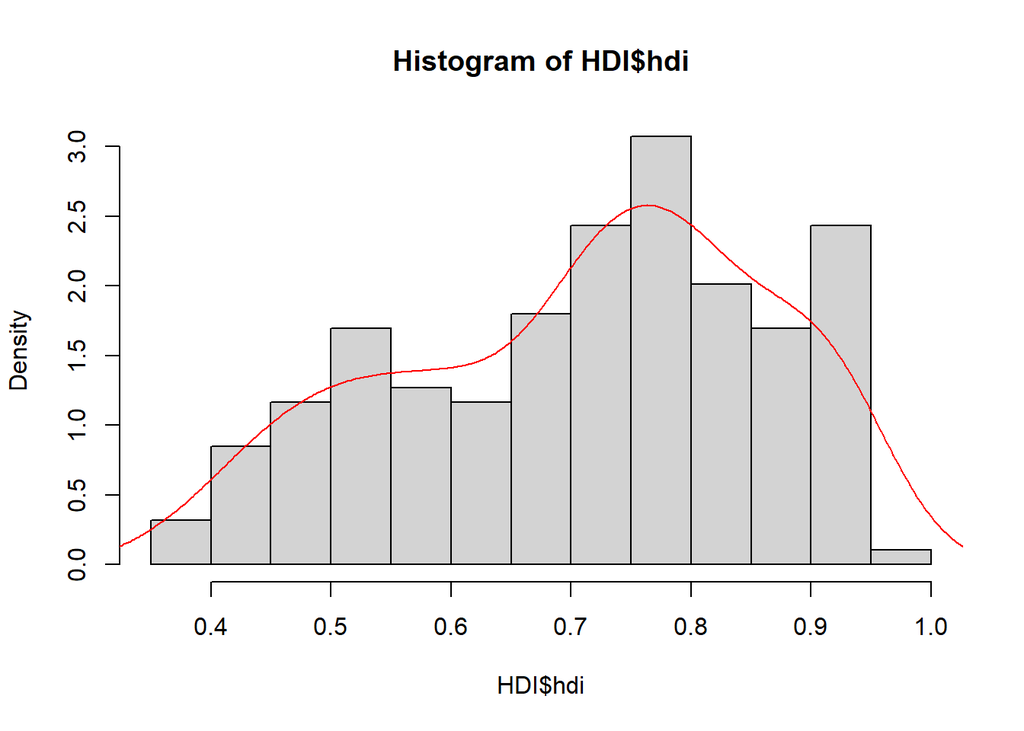

```r
#First, use hist with the argument prob=TRUE to get a histogram scaled by “density”.
#Second, immediately add a density curve to the graph with lines(density(x), col="red"). (where x is the name of the vector; if there are NAs, include na.rm=TRUE in your arguments to density ).
hist(HDI$hdi, prob=TRUE)
lines(density(HDI$hdi, na.rm = TRUE), col = "red")
```

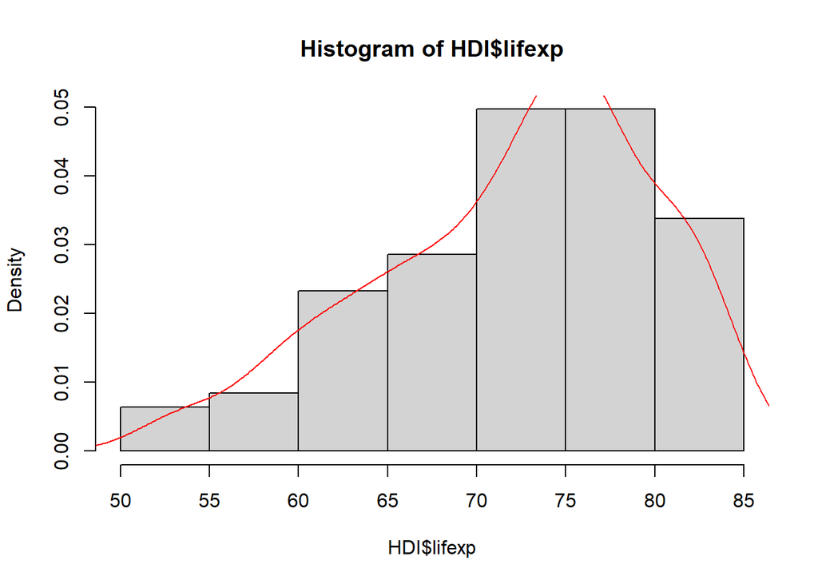

```r
hist(HDI$lifexp, prob=TRUE)
lines(density(HDI$lifexp, na.rm = TRUE), col = "red")
```

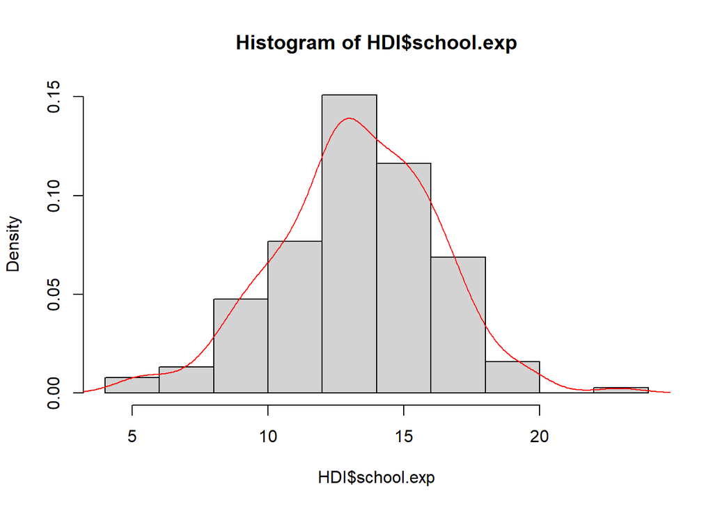

```r
hist(HDI$school.exp, prob=TRUE)
lines(density(HDI$school.exp, na.rm = TRUE), col = "red")
```

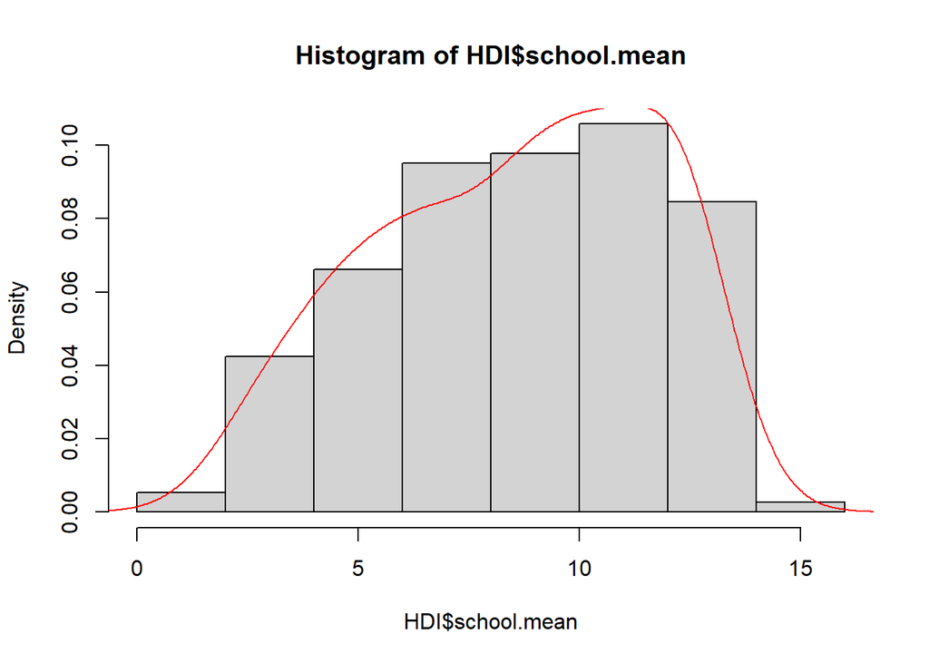

```r
hist(HDI$school.mean, prob=TRUE)
lines(density(HDI$school.mean, na.rm = TRUE), col = "red")
```

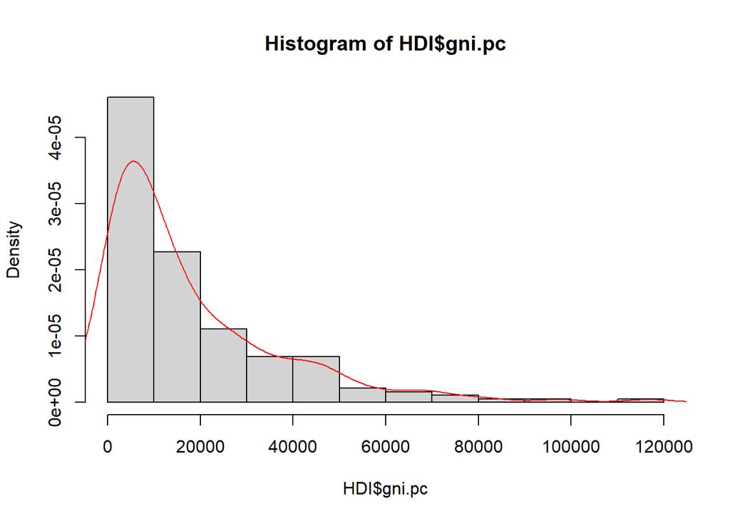

```r
hist(HDI$gni.pc, prob=TRUE)
lines(density(HDI$gni.pc, na.rm = TRUE), col = "red")
```

###Question 5, a: Which of the five distributions looks most Symmetrical?

```r
#school.exp
```

###Question 5, b: Which of the five distributions looks most Left-skewed (i.e., long left “tail”)?

```r
#lifexp
```

###Question 5, c: Which of the five distributions looks most Right-skewed (i.e., long right “tail”)?

```r
#gni.pc
```

###Question 6: How would you describe the distribution of HDI$hdi. Briefly, what does this tell you substantively about “human development” (as measured by the HDI) in the contemporary world?

```r
#bimodal. HDI varies significantly around the world. The majority of the world enjoys a relatively high HDI whereas a significant proportion are still left with a relatively low HDI.
```

##Question 7: The HDI’s income indicator uses the natural logarithm of GNI per capita, rather than GNI per capita itself.